# HC assignment 05

Sai Supriya

2022-11-28

## Hierarchial Clustering

```r
library(readr)
Cereals <- read_csv("Downloads/Cereals.csv")
str(Cereals)
```

```
## spec_tbl_df [77 × 16] (S3: spec_tbl_df/tbl_df/tbl/data.frame)
##  $ name    : chr [1:77] "100%_Bran" "100%_Natural_Bran" "All-Bran" "All-Bran_with_Extra_Fiber" ...
##  $ mfr     : chr [1:77] "N" "Q" "K" "K" ...
##  $ type    : chr [1:77] "C" "C" "C" "C" ...
##  $ calories: num [1:77] 70 120 70 50 110 110 110 130 90 90 ...
##  $ protein : num [1:77] 4 3 4 4 2 2 2 3 2 3 ...
##  $ fat     : num [1:77] 1 5 1 0 2 2 0 2 1 0 ...
##  $ sodium  : num [1:77] 130 15 260 140 200 180 125 210 200 210 ...
##  $ fiber   : num [1:77] 10 2 9 14 1 1.5 1 2 4 5 ...
##  $ carbo   : num [1:77] 5 8 7 8 14 10.5 11 18 15 13 ...
##  $ sugars  : num [1:77] 6 8 5 0 8 10 14 8 6 5 ...
##  $ potass  : num [1:77] 280 135 320 330 NA 70 30 100 125 190 ...
##  $ vitamins: num [1:77] 25 0 25 25 25 25 25 25 25 25 ...
##  $ shelf   : num [1:77] 3 3 3 3 3 1 2 3 1 3 ...
##  $ weight  : num [1:77] 1 1 1 1 1 1 1 1.33 1 1 ...
##  $ cups    : num [1:77] 0.33 1 0.33 0.5 0.75 0.75 1 0.75 0.67 0.67 ...
##  $ rating  : num [1:77] 68.4 34 59.4 93.7 34.4 ...
##  - attr(*, "spec")=
##   .. cols(
##   ..   name = col_character(),
##   ..   mfr = col_character(),
##   ..   type = col_character(),
##   ..   calories = col_double(),
##   ..   protein = col_double(),
##   ..   fat = col_double(),
##   ..   sodium = col_double(),
##   ..   fiber = col_double(),
##   ..   carbo = col_double(),
##   ..   sugars = col_double(),
##   ..   potass = col_double(),
##   ..   vitamins = col_double(),
##   ..   shelf = col_double(),
##   ..   weight = col_double(),
##   ..   cups = col_double(),
##   ..   rating = col_double()
##   .. )
##  - attr(*, "problems")=<externalptr>
```

## Installing & calling required packages

```r
library(tidyverse)## Data manipulation
library(cluster)  ## Clustering Algorithms
library(factoextra) ## Clustering Visualization
library(dendextend)  ## for comparing 2 dendograms
Cereals1<- Cereals[, unlist(lapply(Cereals, is.numeric))]
Cereals1
```

```
## # A tibble: 77 × 13
##    calories protein   fat sodium fiber carbo sugars potass vitamins shelf weight
##       <dbl>   <dbl> <dbl>  <dbl> <dbl> <dbl>  <dbl>  <dbl>    <dbl> <dbl>  <dbl>
##  1       70       4     1    130  10     5        6    280       25     3   1
##  2      120       3     5     15   2     8        8    135        0     3   1
##  3       70       4     1    260   9     7        5    320       25     3   1
##  4       50       4     0    140  14     8        0    330       25     3   1
##  5      110       2     2    200   1    14        8     NA       25     3   1
##  6      110       2     2    180   1.5  10.5     10     70       25     1   1
##  7      110       2     0    125   1    11       14     30       25     2   1
##  8      130       3     2    210   2    18        8    100       25     3   1.33
##  9       90       2     1    200   4    15        6    125       25     1   1
## 10       90       3     0    210   5    13        5    190       25     3   1
## # … with 67 more rows, and 2 more variables: cups <dbl>, rating <dbl>
```

Removing any missing values

```r
Cereals2 <- na.omit(Cereals1)
```

Scaling the data & Normalizing data

```r
Cereals3<- Cereals2[,1:13]
Cereals3<- scale(Cereals2, center = TRUE, scale = TRUE)
head(Cereals3)
```

```
##        calories    protein        fat     sodium       fiber      carbo
## [1,] -1.8659155  1.3817478  0.0000000 -0.3910227  3.22866747 -2.5001396
## [2,]  0.6537514  0.4522084  3.9728810 -1.7804186 -0.07249167 -1.7292632
## [3,] -1.8659155  1.3817478  0.0000000  1.1795987  2.81602258 -1.9862220
## [4,] -2.8737823  1.3817478 -0.9932203 -0.2702057  4.87924705 -1.7292632
## [5,]  0.1498180 -0.4773310  0.9932203  0.2130625 -0.27881412 -1.0868662
## [6,]  0.1498180 -0.4773310 -0.9932203 -0.4514312 -0.48513656 -0.9583868
##          sugars     potass   vitamins      shelf     weight       cups
## [1,] -0.2542051  2.5605229 -0.1818422  0.9419715 -0.2008324 -2.0856582
## [2,]  0.2046041  0.5147738 -1.3032024  0.9419715 -0.2008324  0.7567534
## [3,] -0.4836096  3.1248675 -0.1818422  0.9419715 -0.2008324 -2.0856582
## [4,] -1.6306324  3.2659536 -0.1818422  0.9419715 -0.2008324 -1.3644493
## [5,]  0.6634132 -0.4022862 -0.1818422 -1.4616799 -0.2008324 -0.3038480
## [6,]  1.5810314 -0.9666308 -0.1818422 -0.2598542 -0.2008324  0.7567534
##          rating
## [1,]  1.8549038
## [2,] -0.5977113
## [3,]  1.2151965
## [4,]  3.6578436
## [5,] -0.9165248
## [6,] -0.6553998
```

##Task-1.Apply hierarchical clustering to the data using Euclidean distance to the normalized measurements. #Use Agnes to compare the clustering from single linkage, complete #linkage, average linkage, and Ward. Choose the best method

##Computing the distance matrix Dissimilarity matrix

```r
## Euclidean distance to the normalized measurements.

Euclidean_Distance<- dist(Cereals3, method = "euclidean")
```

###Hierarchial clustering using complete linkage & plotting the obtained dendogram

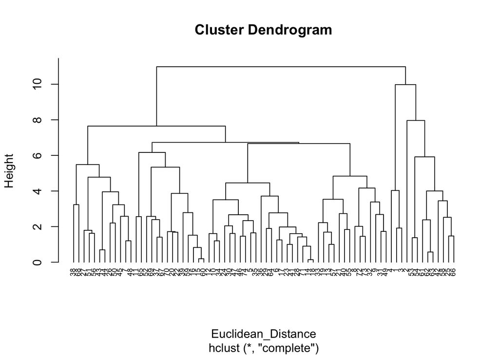

```r
HC1<- hclust(Euclidean_Distance, method = "complete")

plot(HC1, cex=0.6, hang= -1)
```

```r
round(HC1$height, 3)
```

```
##  [1]  0.143  0.196  0.575  0.698  0.828  0.904  1.003  1.004  1.201  1.203
## [11]  1.254  1.378  1.408  1.421  1.454  1.463  1.474  1.517  1.608  1.611
## [21]  1.616  1.625  1.650  1.687  1.692  1.720  1.730  1.795  1.839  1.897
## [31]  1.919  1.982  2.015  2.046  2.203  2.224  2.339  2.381  2.394  2.522
## [41]  2.563  2.574  2.579  2.668  2.682  2.734  2.776  2.787  3.229  3.236
## [51]  3.385  3.451  3.510  3.535  3.717  3.866  3.957  4.005  4.031  4.168
## [61]  4.456  4.779  4.839  5.342  5.488  5.920  6.169  6.669  6.731  7.650
## [71]  7.964  9.979 10.984
```

## Using agnes and other to find best option

```r
library(cluster)
## Use Agnes to compare the clustering from  single linkage, complete linkage, average linkage, and Ward.


HC_single <- agnes(Cereals3, method="single")
HC_complete <- agnes(Cereals3, method = "complete")
HC_average <- agnes(Cereals3, method = "average")
HC_ward<- agnes(Cereals3, method = "ward")

print(HC_single$ac)
```

```
## [1] 0.6067859
```

```r
print(HC_complete$ac)
```

```
## [1] 0.8353712
```

```r
print(HC_average$ac)
```

```
## [1] 0.7766075
```

```r
print(HC_ward$ac)
```

```
## [1] 0.9046042
```

It can be infered that the ac ( agglomerate coefficient for ward method is greater than the other two methods.)

## Using the dendrogram to find optimal no. of clusters

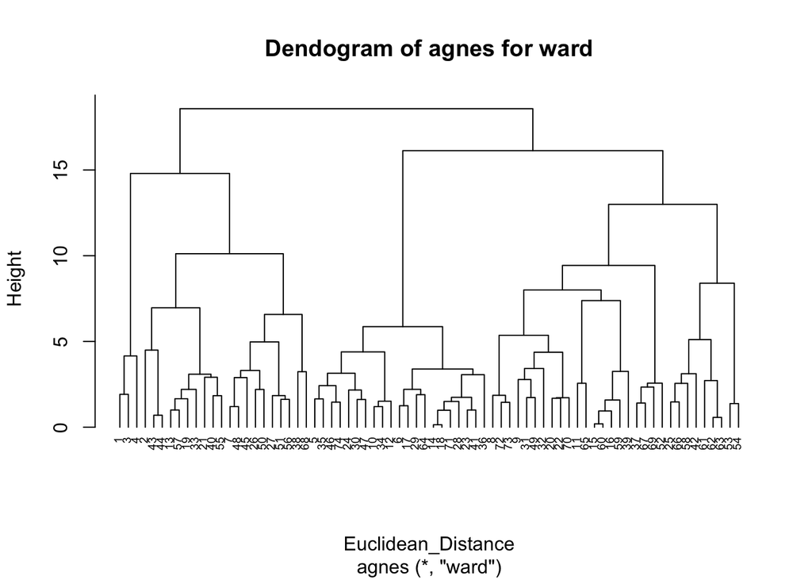

```r
HC_ward<- agnes(Euclidean_Distance, method = "ward")
pltree(HC_ward, cex= 0.6, hang= -1 , main= "Dendogram of agnes for ward")
```

#### Divisive clustering

```r
hc_4<- diana(Cereals3)
hc_4$dc
```

```
## [1] 0.8302148
```

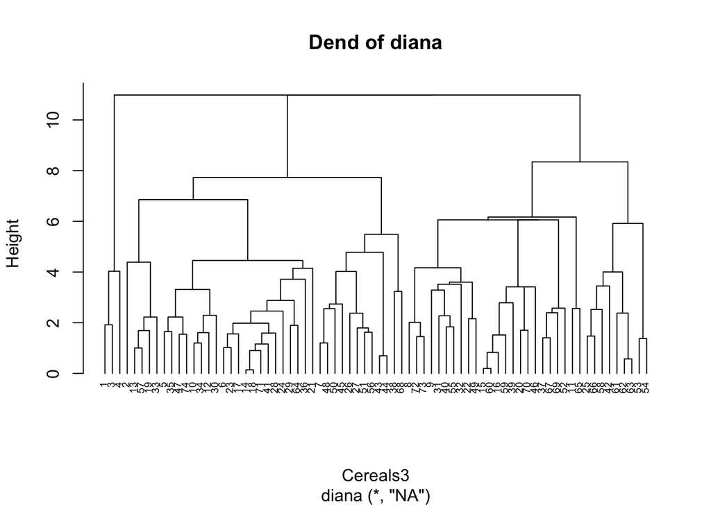

```r
pltree(hc_4, cex=0.6, hang=-1, main="Dend of diana")
```

##“Srength of the endogram is observed to be 83%”

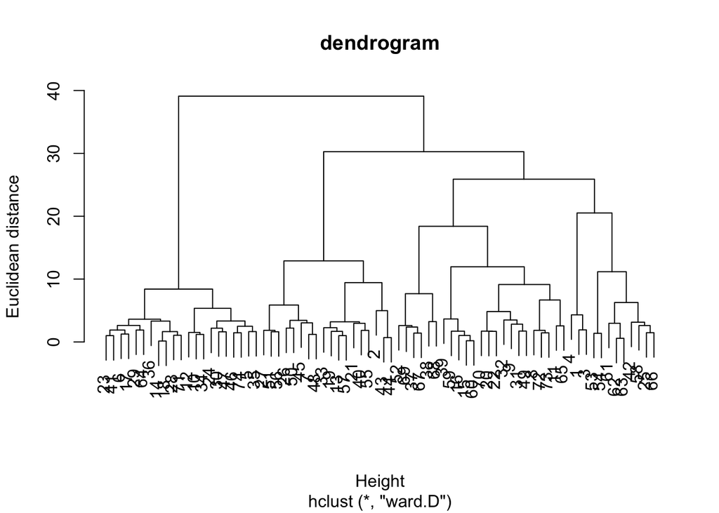

```r
dendrogram= hclust(dist(Cereals3, method = 'euclidean'), method = 'ward.D')
plot(dendrogram, main= paste('dendrogram'),
xlab= 'Height',
ylab= 'Euclidean distance')
```

##Fitting hierarchial clustering model

```r
hc5= hclust(dist(Cereals3, method = 'euclidean'), method = 'ward.D2')


## Cut tree into 5 groups

sub_grp = cutree(hc5, k=5)

##Number of in each clusters
table(sub_grp)
```

```
## sub_grp
##  1  2  3  4  5
##  3 20 21 21  9
```

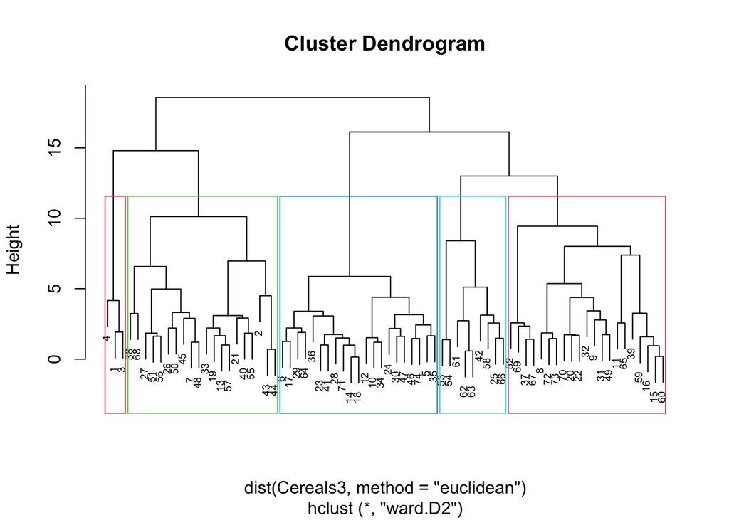

```r
##
plot(hc5, cex=0.6)
rect.hclust(hc5, k=5, border = 2:5,)
```

```r
Bind_clus<- cbind.data.frame(cbind(Cereals3, sub_grp))
```

##Determing optimal clusters

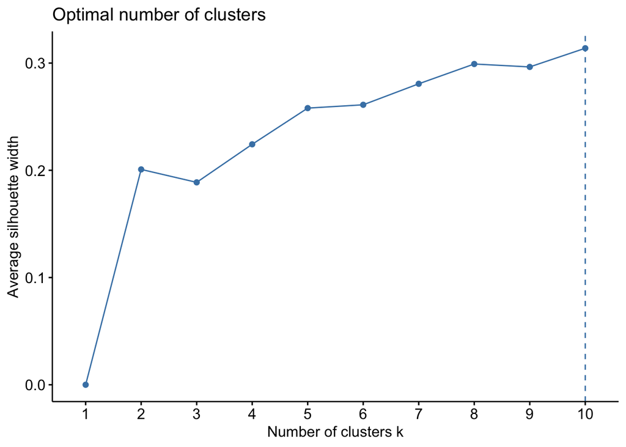

```r
library(cluster)
library(factoextra)
fviz_nbclust(Cereals3, FUN = hcut, method = "silhouette")
```

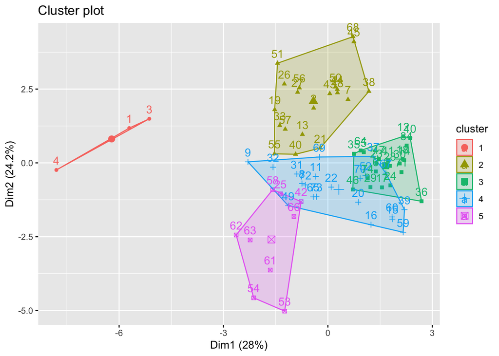

```r
fviz_cluster(list(data= Cereals3, cluster= sub_grp))
```

###3)The elementary public schools would like to choose a set of cereals to include in their #daily cafeterias. Every day a different cereal is offered, but all cereals should support a #healthy diet. For this goal, you are requested to find a cluster of “healthy cereals.”

```r
Healthy_cereals<- cbind(Cereals2,sub_grp)
mean(Healthy_cereals[Healthy_cereals$sub_grp==1, "rating"])
```

```
## [1] 73.84446
```

```r
mean(Healthy_cereals[Healthy_cereals$sub_grp==2,"rating"])
```

```
## [1] 38.26161
```

```r
mean(Healthy_cereals[Healthy_cereals$sub_grp==3,"rating"])
```

```
## [1] 28.84825
```

```r
mean(Healthy_cereals[Healthy_cereals$sub_grp==4,"rating"])
```

```
## [1] 46.46513
```

```r
mean(Healthy_cereals[Healthy_cereals$sub_grp==5,"rating"])
```

```
## [1] 63.0184
```

```r
##Therefore from the above observations it can be infered that the first cluster is given the high rating as the healthiest cereals of all the other 4.
```